# hw6

LuchaoQi

November 27, 2018

### Problem 1

### Problem 2

1. Null: $H_0 : \hat{RD} = \hat{p1} - \hat{p2} = 0$  
   Alternative: $H_A : \hat{p1} - \hat{p2} \neq0$  
   ${\hat{SE}}_{\hat{RD}}=\sqrt{\frac{\hat{p1}(1-\hat{p1})}{n_1}+\frac{\hat{p2}(1-\hat{p2})}{n_2}}$

```r
x=2/15
y=4/19
p=60/340
z=(y-x)/sqrt(p*(1-p)*(1/150+1/190))
2*(1-pnorm(z))
```

```
## [1] 0.06375422
```

```r
x=21/152
y=41/192
(x-y)+c(-1,1)*qnorm(0.975)*sqrt(x*(1-x)/152+y*(1-y)/192)
```

```
## [1] -0.155191935  0.004424391
```

```r
x=20/150
y=40/190
se=sqrt((1-x)/(x*150)+(1-y)/(y*190))
log=log(x/y)+c(-1,1)*1.96*se
exp(log)
```

```
## [1] 0.3871324 1.0361082
```

For odds ratio:  
CI = [0.3211208 1.0364953]

```r
n11=20
n12=130
n21=40
n22=150
n=(n11*n22)/(n12*n21)
se=sqrt(1/n11+1/n12+1/n21+1/n22)
log=log(n)+c(-1,1)*se*qnorm(0.975)
exp(log)
```

```
## [1] 0.3211208 1.0364953
```

Bayesian credible intervals:

```r
x1 = 20; n1 = 150
x2 = 40; n2 = 190
alpha1 = 1; beta1 = 1
alpha2 = 1; beta2 = 1
p1 = rbeta(1000,x1+alpha1, n1-x1+beta1)
p2 = rbeta(1000,x2+alpha2, n2-x2+beta2)
```

For RD:

```r
rd = p1-p2
quantile(rd,c(.025,.975))
```

```
##         2.5%        97.5%
## -0.158313193  0.001174952
```

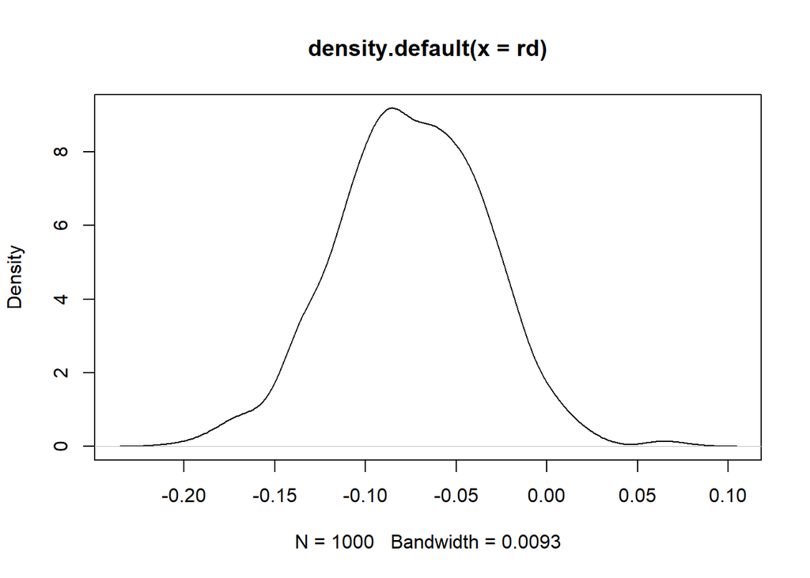

```r
plot(density(rd))
```

For RR:

```r
rr = p1/p2
quantile(rr,c(0.025,0.975))
```

```
##      2.5%     97.5%
## 0.3796838 1.0067501
```

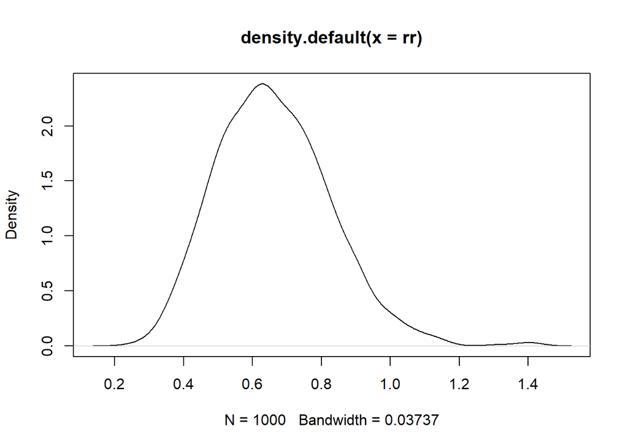

```r
plot(density(rr))
```

For OR:

```r
or = p1/(1-p1)/(p2/(1-p2))
quantile(or,c(0.025,0.975))
```

```
##      2.5%     97.5%
## 0.3169104 1.0081844
```

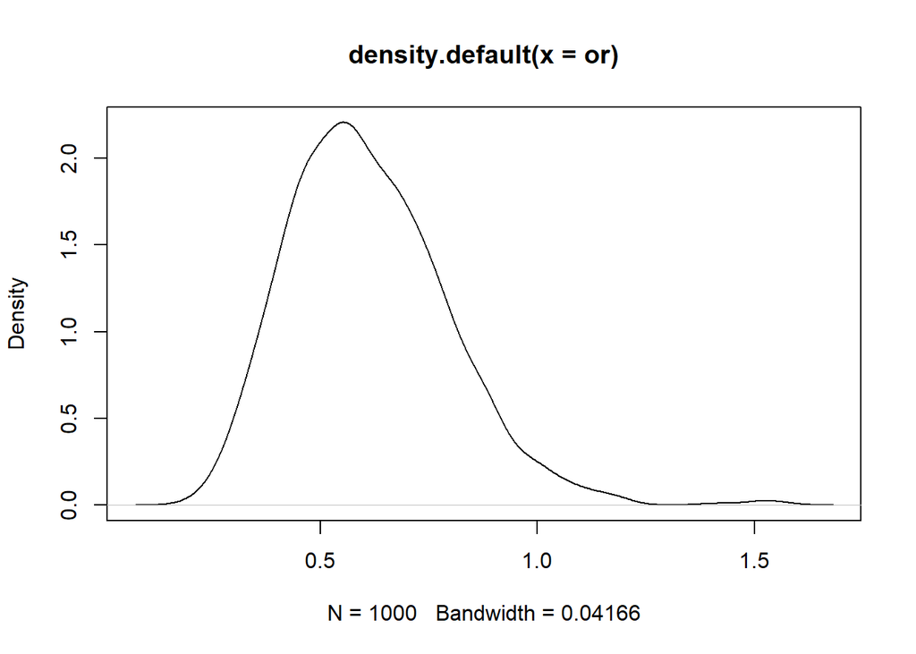

```r
plot(density(or))
```

### Problem 3

95% CI =
$$[log(\frac{x}{n})-1.96*\sqrt{\frac{1}{x}-\frac{1}{n}},log(\frac{x}{n})+1.96*\sqrt{\frac{1}{x}-\frac{1}{n}}]$$

### problem 4

1. ${\frac{\hat{p}-p}{\hat{SE}_\hat{p}}}\to N(0,1)$  
   ${\frac{\sqrt{\hat{p}}-\sqrt{p}}{\frac{1}{2\sqrt{\hat{p}}}\hat{SE}_\hat{p}} }\to N(0,1)$  
   So standard error for $\sqrt{\hat{p}}$ is $\sqrt{\frac{1-\hat{p}}{4n}}$
2. Simulation:

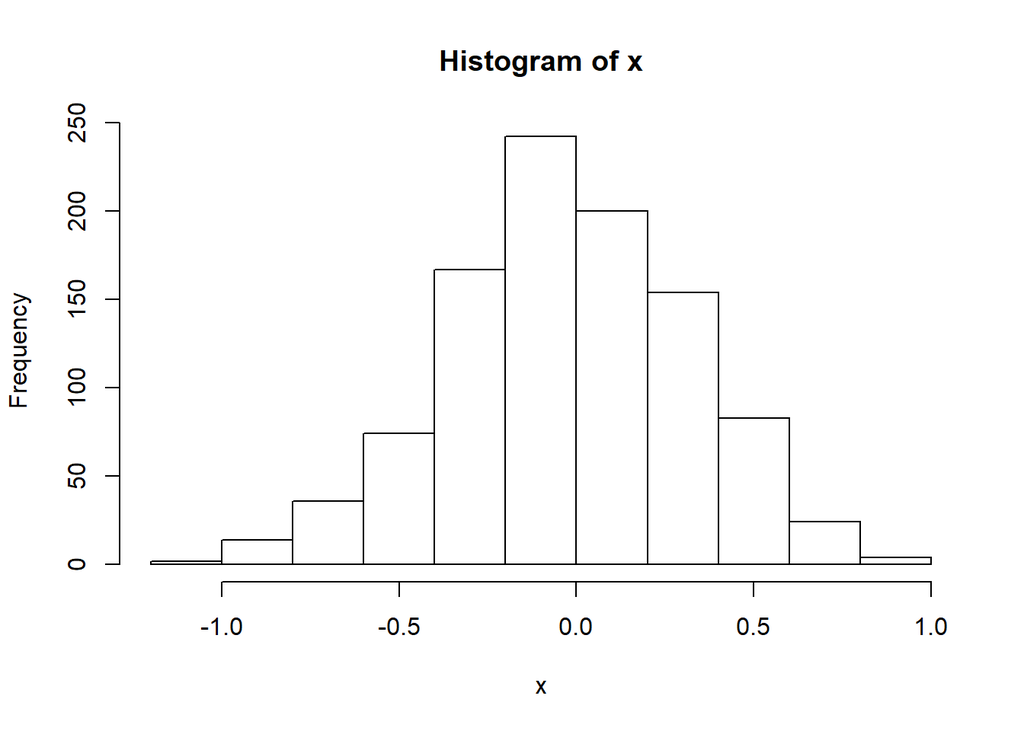

```r
x=rep(0,length=1000)
for (i in 1:1000){
x[i]=(sqrt(mean(rbinom(200,1,0.5)))-sqrt(0.5))/((1-sqrt(mean(rbinom(200,1,0.5))))/4)
}
hist(x)
```

### Problem 5

For $p1 = .1; p2 = .1; n1 = 100; n2 = 100$ :

```r
p1 = .1; p2 = .1; n1 = 100; n2 = 100
p = log(p1*(1-p2)/((p2)*(1-p1)))
x=rbinom(1000,n1,p1)
y=rbinom(1000,n2,p2)
z=cbind(x,y)
OR = apply(z, 1, function(x) x[1] * (n2 - x[2]) / (x[2] * (n1 - x[1])) )
SELOGOR = apply(z, 1, function(x) sqrt(1 / x[1] + 1 / (n1 - x[1]) + 1 / x[2] + 1 / (n2 - x[2]) ) )
INTERVAL = cbind(log(OR)-1.96*SELOGOR,log(OR)+1.96*SELOGOR)
s=0
for (i in 1:1000) {
  if (p>=INTERVAL[i,1] & p<=INTERVAL[i,2]){
    s= s+1
  }
}
s/1000
```

```
## [1] 0.962
```

For $p1 = .1; p2 = .5; n1 = 100; n2 = 100$:

```r
p1 = .1; p2 = .5; n1 = 100; n2 = 100
p = log(p1*(1-p2)/((p2)*(1-p1)))
x=rbinom(1000,n1,p1)
y=rbinom(1000,n2,p2)
z=cbind(x,y)
OR = apply(z, 1, function(x) x[1] * (n2 - x[2]) / (x[2] * (n1 - x[1])) )
SELOGOR = apply(z, 1, function(x) sqrt(1 / x[1] + 1 / (n1 - x[1]) + 1 / x[2] + 1 / (n2 - x[2]) ) )
INTERVAL = cbind(log(OR)-1.96*SELOGOR,log(OR)+1.96*SELOGOR)
s=0
for (i in 1:1000) {
  if (p>=INTERVAL[i,1] & p<=INTERVAL[i,2]){
    s= s+1
  }
}
s/1000
```

```
## [1] 0.961
```

For $p1 = .1; p2 = .9; n1 = 100; n2 = 100$:

```r
p1 = .1; p2 = .9; n1 = 100; n2 = 100
p = log(p1*(1-p2)/((p2)*(1-p1)))
x=rbinom(1000,n1,p1)
y=rbinom(1000,n2,p2)
z=cbind(x,y)
OR = apply(z, 1, function(x) x[1] * (n2 - x[2]) / (x[2] * (n1 - x[1])) )
SELOGOR = apply(z, 1, function(x) sqrt(1 / x[1] + 1 / (n1 - x[1]) + 1 / x[2] + 1 / (n2 - x[2]) ) )
INTERVAL = cbind(log(OR)-1.96*SELOGOR,log(OR)+1.96*SELOGOR)
s=0
for (i in 1:1000) {
  if (p>=INTERVAL[i,1] & p<=INTERVAL[i,2]){
    s= s+1
  }
}
s/1000
```

```
## [1] 0.962
```

For $p1 = .5; p2 = .5; n1 = 100; n2 = 100$:

```r
p1 = .5; p2 = .5; n1 = 100; n2 = 100
p = log(p1*(1-p2)/((p2)*(1-p1)))
x=rbinom(1000,n1,p1)
y=rbinom(1000,n2,p2)
z=cbind(x,y)
OR = apply(z, 1, function(x) x[1] * (n2 - x[2]) / (x[2] * (n1 - x[1])) )
SELOGOR = apply(z, 1, function(x) sqrt(1 / x[1] + 1 / (n1 - x[1]) + 1 / x[2] + 1 / (n2 - x[2]) ) )
INTERVAL = cbind(log(OR)-1.96*SELOGOR,log(OR)+1.96*SELOGOR)
s=0
for (i in 1:1000) {
  if (p>=INTERVAL[i,1] & p<=INTERVAL[i,2]){
    s= s+1
  }
}
s/1000
```

```
## [1] 0.939
```

For $p1 = .5; p2 = .9; n1 = 100; n2 = 100$:

```r
p1 = .5; p2 = .9; n1 = 100; n2 = 100
p = log(p1*(1-p2)/((p2)*(1-p1)))
x=rbinom(1000,n1,p1)
y=rbinom(1000,n2,p2)
z=cbind(x,y)
OR = apply(z, 1, function(x) x[1] * (n2 - x[2]) / (x[2] * (n1 - x[1])) )
SELOGOR = apply(z, 1, function(x) sqrt(1 / x[1] + 1 / (n1 - x[1]) + 1 / x[2] + 1 / (n2 - x[2]) ) )
INTERVAL = cbind(log(OR)-1.96*SELOGOR,log(OR)+1.96*SELOGOR)
s=0
for (i in 1:1000) {
  if (p>=INTERVAL[i,1] & p<=INTERVAL[i,2]){
    s= s+1
  }
}
s/1000
```

```
## [1] 0.958
```

For $p1 = .9; p2 = .9; n1 = 100; n2 = 100$:

```r
p1 = .9; p2 = .9; n1 = 100; n2 = 100
p = log(p1*(1-p2)/((p2)*(1-p1)))
x=rbinom(1000,n1,p1)
y=rbinom(1000,n2,p2)
z=cbind(x,y)
OR = apply(z, 1, function(x) x[1] * (n2 - x[2]) / (x[2] * (n1 - x[1])) )
SELOGOR = apply(z, 1, function(x) sqrt(1 / x[1] + 1 / (n1 - x[1]) + 1 / x[2] + 1 / (n2 - x[2]) ) )
INTERVAL = cbind(log(OR)-1.96*SELOGOR,log(OR)+1.96*SELOGOR)
s=0
for (i in 1:1000) {
  if (p>=INTERVAL[i,1] & p<=INTERVAL[i,2]){
    s= s+1
  }
}
s/1000
```

```
## [1] 0.967
```

Summary: There’s no big difference in intervals’ performance

### Problem 6

For $p1 = .1; p2 = .1; n1 = 100; n2 = 100$:

```r
p1 = .1; p2 = .1; n1 = 100; n2 = 100
p = log(p1/p2)
x=rbinom(1000,n1,p1)
y=rbinom(1000,n2,p2)
z=cbind(x,y)
RR = apply(z, 1,
function(x) (x[1] / n1) / (x[2] / n2))
SELOGRR = apply(z, 1,
function(x) {
phat1 <- x[1] / n1
phat2 <- x[2] / n2
sqrt((1 - phat1) / phat1 / n1 + (1 - phat2) / phat2 / n2)
})
INTERVAL = cbind(log(OR)-1.96*SELOGOR,log(OR)+1.96*SELOGOR)
s=0
for (i in 1:1000) {
  if (p>= INTERVAL[i,1] & p<=INTERVAL[i,2]){
    s= s+1
  }
}
s/1000
```

```
## [1] 0.967
```

For $p1 = .1; p2 = .5; n1 = 100; n2 = 100$

```r
p1 = .1; p2 = .5; n1 = 100; n2 = 100
p = log(p1/p2)
x=rbinom(1000,n1,p1)
y=rbinom(1000,n2,p2)
z=cbind(x,y)
RR = apply(z, 1,
function(x) (x[1] / n1) / (x[2] / n2))
SELOGRR = apply(z, 1,
function(x) {
phat1 <- x[1] / n1
phat2 <- x[2] / n2
sqrt((1 - phat1) / phat1 / n1 + (1 - phat2) / phat2 / n2)
})
INTERVAL = cbind(log(RR)-1.96*SELOGRR,log(RR)+1.96*SELOGRR)
s=0
for (i in 1:1000) {
  if (p>= INTERVAL[i,1] & p<=INTERVAL[i,2]){
    s= s+1
  }
}
s/1000
```

```
## [1] 0.96
```

For $p1 = .1; p2 = .9; n1 = 100; n2 = 100$

```r
p1 = .1; p2 = .9; n1 = 100; n2 = 100
p = log(p1/p2)
x=rbinom(1000,n1,p1)
y=rbinom(1000,n2,p2)
z=cbind(x,y)
RR = apply(z, 1,
function(x) (x[1] / n1) / (x[2] / n2))
SELOGRR = apply(z, 1,
function(x) {
phat1 <- x[1] / n1
phat2 <- x[2] / n2
sqrt((1 - phat1) / phat1 / n1 + (1 - phat2) / phat2 / n2)
})
INTERVAL = cbind(log(RR)-1.96*SELOGRR,log(RR)+1.96*SELOGRR)
s=0
for (i in 1:1000) {
  if (p>= INTERVAL[i,1] & p<=INTERVAL[i,2]){
    s= s+1
  }
}
s/1000
```

```
## [1] 0.958
```

For $p1 = .5; p2 = .5; n1 = 100; n2 = 100$

```r
p1 = .5; p2 = .5; n1 = 100; n2 = 100
p = log(p1/p2)
x=rbinom(1000,n1,p1)
y=rbinom(1000,n2,p2)
z=cbind(x,y)
RR = apply(z, 1,
function(x) (x[1] / n1) / (x[2] / n2))
SELOGRR = apply(z, 1,
function(x) {
phat1 <- x[1] / n1
phat2 <- x[2] / n2
sqrt((1 - phat1) / phat1 / n1 + (1 - phat2) / phat2 / n2)
})
INTERVAL = cbind(log(RR)-1.96*SELOGRR,log(RR)+1.96*SELOGRR)
s=0
for (i in 1:1000) {
  if (p>= INTERVAL[i,1] & p<=INTERVAL[i,2]){
    s= s+1
  }
}
s/1000
```

```
## [1] 0.952
```

For $p1 = .5; p2 = .9; n1 = 100; n2 = 100$

```r
p1 = .5; p2 = .9; n1 = 100; n2 = 100
p = log(p1/p2)
x=rbinom(1000,n1,p1)
y=rbinom(1000,n2,p2)
z=cbind(x,y)
RR = apply(z, 1,
function(x) (x[1] / n1) / (x[2] / n2))
SELOGRR = apply(z, 1,
function(x) {
phat1 <- x[1] / n1
phat2 <- x[2] / n2
sqrt((1 - phat1) / phat1 / n1 + (1 - phat2) / phat2 / n2)
})
INTERVAL = cbind(log(RR)-1.96*SELOGRR,log(RR)+1.96*SELOGRR)
s=0
for (i in 1:1000) {
  if (p>= INTERVAL[i,1] & p<=INTERVAL[i,2]){
    s= s+1
  }
}
s/1000
```

```
## [1] 0.951
```

For $p1 = .9; p2 = .9; n1 = 100; n2 = 100$

```r
p1 = .9; p2 = .9; n1 = 100; n2 = 100
p = log(p1/p2)
x=rbinom(1000,n1,p1)
y=rbinom(1000,n2,p2)
z=cbind(x,y)
RR = apply(z, 1,
function(x) (x[1] / n1) / (x[2] / n2))
SELOGRR = apply(z, 1,
function(x) {
phat1 <- x[1] / n1
phat2 <- x[2] / n2
sqrt((1 - phat1) / phat1 / n1 + (1 - phat2) / phat2 / n2)
})
INTERVAL = cbind(log(RR)-1.96*SELOGRR,log(RR)+1.96*SELOGRR)
s=0
for (i in 1:1000) {
  if (p>= INTERVAL[i,1] & p<=INTERVAL[i,2]){
    s= s+1
  }
}
s/1000
```

```
## [1] 0.945
```

Summary: There’s no big difference in intervals’ performance

### Problem 7

1. The 95% CI of the odds ratio is [2.055483 10.624095]

```r
n11=243
n12=259-243
n21=39
n22=51-39
OR = n11*n22/(n21*n12)
SE = sqrt(1/n11+1/n12+1/n21+1/n22)
INTERVAL = exp(c(log(OR)-1.96*SE,log(OR)+1.96*SE))
OR
```

```
## [1] 4.673077
```

```r
INTERVAL
```

```
## [1]  2.055483 10.624095
```

2. The 95% CI of the relative risk is [1.050307 1.433203]

```r
n1=259
n2=51
p1=243/259
p2=39/51
RR=p1/p2
SE = sqrt((1-p1)/(p1*n1)+(1-p2)/(p2*n2))
INTERVAL = exp(c(log(RR)-1.96*SE,log(RR)+1.96*SE))
RR
```

```
## [1] 1.226908
```

```r
INTERVAL
```

```
## [1] 1.050307 1.433203
```

3. The 95% CI of the risk difference is [0.05346365 0.29357246]

```r
n1=259
n2=51
p1=243/259
p2=39/51
RD=p1 - p2
SE = sqrt(p1*(1-p1)/n1+p2*(1-p2)/n2)
INTERVAL=c(RD-1.96*SE,RD+1.96*SE)
RD
```

```
## [1] 0.1735181
```

```r
INTERVAL
```

```
## [1] 0.05346365 0.29357246
```

4. $H_0 : p1 = p2$  
   $H_A : p1\neq p2$  
   p-value = 7.767783e-05 < 0.05, so we reject the null and conclude that $p1\neq p2$

```r
O11=243;E11=282/310*259
O21=39;E21=282/310*51
O12=16;E12=28/310*259
O22=12;E22=28/310*51
TS = sum((O11-E11)^2/E11,(O12-E12)^2/E12,(O21-E21)^2/E21,(O22-E22)^2/E22)
pchisq(TS,1,lower.tail = FALSE)
```

```
## [1] 7.767783e-05
```

Or we could use following codes:

```r
dat = matrix(c(243,16,39,12),2)
chisq.test(dat, correct = FALSE)
```

```
##
##  Pearson's Chi-squared test
##
## data:  dat
## X-squared = 15.614, df = 1, p-value = 7.768e-05
```

### Problem 8

95% CI of the odds ratio is [3.649598 10.925327]

```r
n11=50;n12=61
n21=27;n22=208
OR = n11*n22/(n12*n21)
SE = sqrt(1/n11+1/n12+1/n21+1/n22)
exp(c(log(OR)-1.96*SE,log(OR)+1.96*SE))
```

```
## [1]  3.649598 10.925327
```

### Problem 9

```r
dat = matrix(c(50,10,20,40),2)
chisq.test(dat, correct = FALSE)
```

```
##
##  Pearson's Chi-squared test
##
## data:  dat
## X-squared = 30.857, df = 1, p-value = 2.777e-08
```

### Problem 10

95% CI =
$$[log(\frac{\hat{p}}{1-\hat{p}})-1.96\frac{1}{\hat{p}(1-\hat{p})}\sqrt{\hat{p}(1-\hat{p})/n},log(\frac{\hat{p}}{1-\hat{p}})+1.96\frac{1}{\hat{p}(1-\hat{p})}\sqrt{\hat{p}(1-\hat{p})/n}]$$

### Problem 11

95% CI =
$$[
log(\frac{\hat{p1}}{1-\hat{p1}})-log(\frac{\hat{p2}}{1-\hat{p2}})-\frac{1.96}{(\frac{1}{\hat{p1}(1-\hat{p1})}-\frac{1}{\hat{p2}(1-\hat{p2})})}(\sqrt{\hat{p1}(1-\hat{p1})/n}+\sqrt{\hat{p2}(1-\hat{p2})/n}),$$
$$log(\frac{\hat{p1}}{1-\hat{p1}})-log(\frac{\hat{p2}}{1-\hat{p2}})+\frac{1.96}{(\frac{1}{\hat{p1}(1-\hat{p1})}-\frac{1}{\hat{p2}(1-\hat{p2})})}(\sqrt{\hat{p1}(1-\hat{p1})/n}+\sqrt{\hat{p2}(1-\hat{p2})/n})
]$$

### Problem 12

1. $H_0 : p1 = p2$  
   $H_A : p1 > p2$  
   Using score test:

```r
p1=30/40
p2=10/40
p=40/80
TS = (p1-p2)/sqrt(p*(1-p)*(2/40))
```

TS = 4.472136 > qnorm(0.95) = 1.644854. So we reject the null, meaning Drug A has a higher probability of side effect than Drug B.

2. For odds ratio:  
   95% CI = [3.270965 24.763337]

```r
n11 = 30;n12 = 10; n21= 10; n22= 30
OR = n11*n22/(n12*n21)
SE = sqrt(1/n11+1/n12+1/n21+1/n22)
INTERVAL = exp(c(log(OR)-1.96*SE,log(OR)+1.96*SE))
INTERVAL
```

```
## [1]  3.270965 24.763337
```

For relative risk:  
95% CI = [1.703711 5.282585]

```r
p1=30/40
p2=10/40
RR = p1/p2
SE = sqrt((1-p1)/(p1*40)+(1-p2)/(p2*40))
INTERVAL = exp(c(log(RR)-1.96*SE,log(RR)+1.96*SE))
INTERVAL
```

```
## [1] 1.703711 5.282585
```

For risk difference:  
95% CI = [0.3102238 0.6897762]

```r
p1=30/40
p2=10/40
RD=p1-p2
SE = sqrt(p1*(1-p1)/40+p2*(1-p2)/40)
INTERVAL = c(RD-1.96*SE,RD+1.96*SE)
INTERVAL
```

```
## [1] 0.3102238 0.6897762
```

### Problem 13

Using score test:  
$H_0 : p=0.5$  
$H_A : p\neq0.5$

```r
pbinom(7,10,0.5,lower.tail = FALSE)
```

```
## [1] 0.0546875
```

p-value = 0.0546875 > 0.05 , so we fail to reject the hypothesis that the coin is fair.